# CMPINF 2130 Summer 2021 - Week 03

## Other variables

We have created grahpics up to this point to visualize 2 continuous and 1 categorical. We have mapped the categorical to multiple aesthetics and used facets to distinguish between the groups.

Can we represent all of the variables in the `iris` data set?

```r
iris %>% summary()
```

```
##   Sepal.Length    Sepal.Width     Petal.Length    Petal.Width
##  Min.   :4.300   Min.   :2.000   Min.   :1.000   Min.   :0.100
##  1st Qu.:5.100   1st Qu.:2.800   1st Qu.:1.600   1st Qu.:0.300
##  Median :5.800   Median :3.000   Median :4.350   Median :1.300
##  Mean   :5.843   Mean   :3.057   Mean   :3.758   Mean   :1.199
##  3rd Qu.:6.400   3rd Qu.:3.300   3rd Qu.:5.100   3rd Qu.:1.800
##  Max.   :7.900   Max.   :4.400   Max.   :6.900   Max.   :2.500
##        Species
##  setosa    :50
##  versicolor:50
##  virginica :50
##
##
##
```

Let’s create a scatter plot between the Petal variables, just like we did for the Sepal variables.

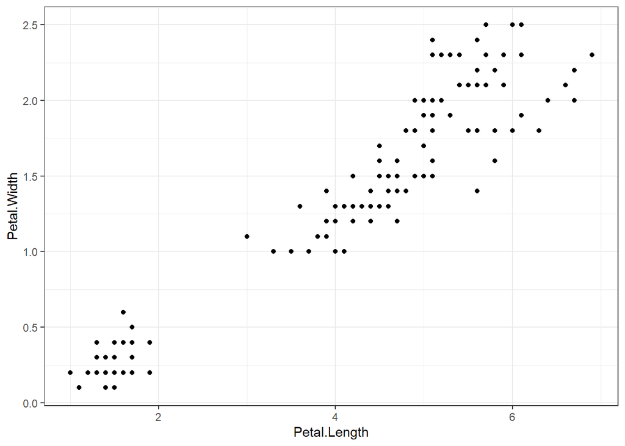

```r
iris %>%
  ggplot(mapping = aes(x = Petal.Length, y = Petal.Width)) +
  geom_point() +
  theme_bw()
```

Check the correlation coefficient between the two Petal variables.

```r
iris %>%
  select(starts_with("Petal.")) %>%
  cor()
```

```
##              Petal.Length Petal.Width
## Petal.Length    1.0000000   0.9628654
## Petal.Width     0.9628654   1.0000000
```

Can visualize our scatter plot colored by Species.

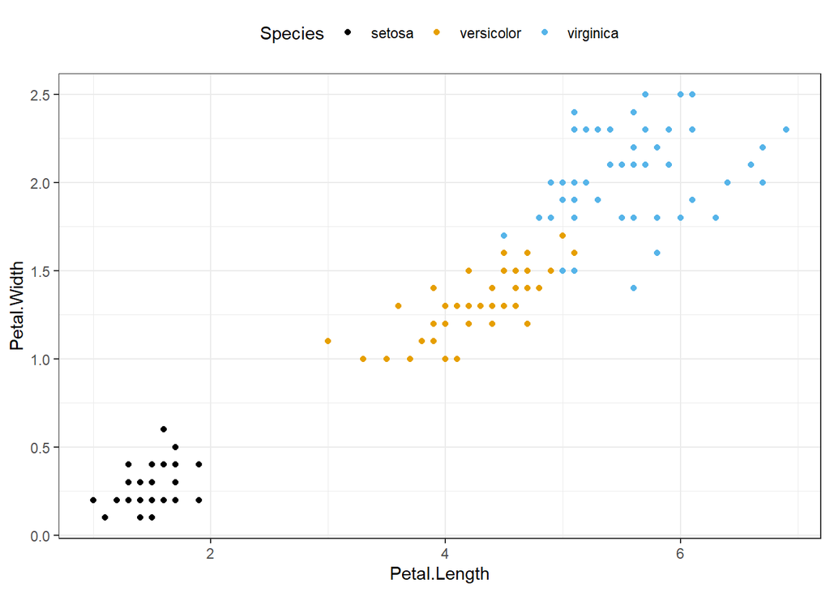

```r
iris %>%
  ggplot(mapping = aes(x = Petal.Length, y = Petal.Width)) +
  geom_point(mapping = aes(color = Species)) +
  ggthemes::scale_color_colorblind() +
  theme_bw() +
  theme(legend.position = "top")
```

Start to bring the Petal variables INTO the visualization of the Sepal variables. We have used color to denote a categorical variable, but color can also be used to represent a continuous variable! A continuous variable has a **sequential** order. We want to preserve that sequential order of the values. So the color scales for continuous variables are usually denoted as sequential. We can also have diverging scales, to represent a sequential order **away** from a central point (in two directions).

Let’s make a scatter plot between the Sepal variables with the `Petal.Length` represented by the color.

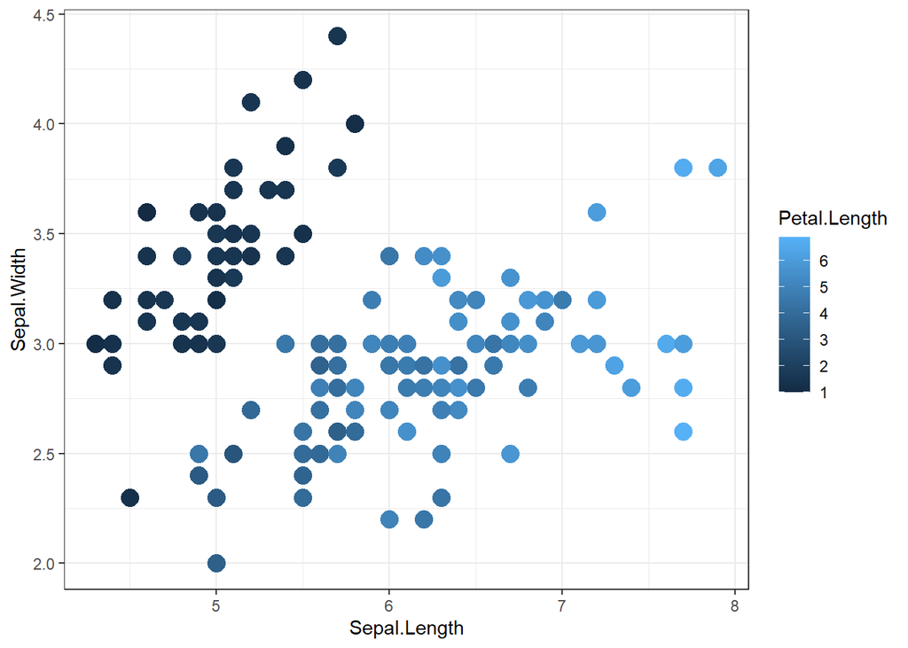

```r
iris %>%
  ggplot(mapping = aes(x = Sepal.Length, y = Sepal.Width)) +
  geom_point(mapping = aes(color = Petal.Length),
             size = 4.5) +
  theme_bw()
```

The default continuous color scale function is `scale_color_continuous()`.

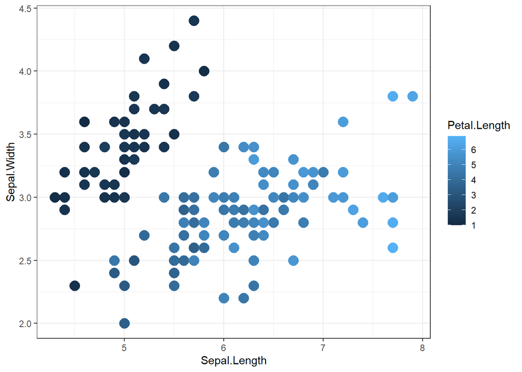

```r
iris %>%
  ggplot(mapping = aes(x = Sepal.Length, y = Sepal.Width)) +
  geom_point(mapping = aes(color = Petal.Length),
             size = 4.5) +
  scale_color_continuous() +
  theme_bw()
```

I don’t like the default color scale for continuous variables. I pretty much always switch to the viridis color palettes for sequential colors. The viridis color palette is controlled by the `scale_*_viridis_c()` for continuous colors.

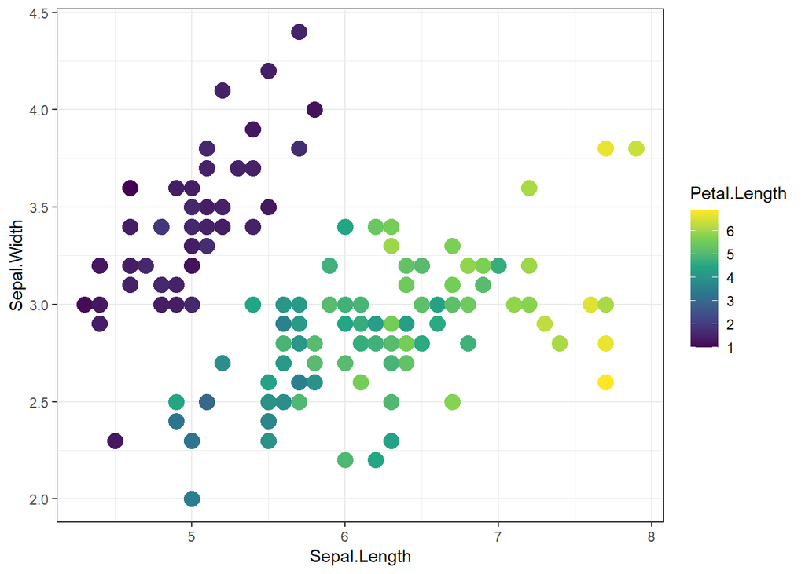

```r
iris %>%
  ggplot(mapping = aes(x = Sepal.Length, y = Sepal.Width)) +
  geom_point(mapping = aes(color = Petal.Length),
             size = 4.5) +
  scale_color_viridis_c() +
  theme_bw()
```

Other options exist within the viridis set of colors.

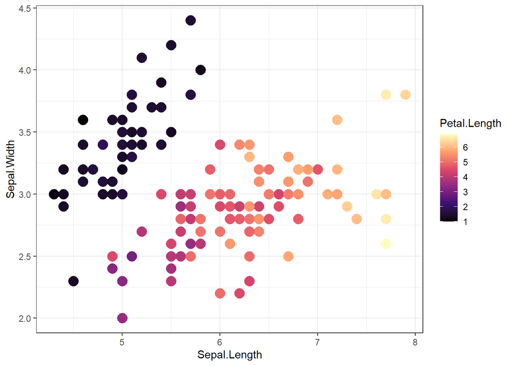

```r
iris %>%
  ggplot(mapping = aes(x = Sepal.Length, y = Sepal.Width)) +
  geom_point(mapping = aes(color = Petal.Length),
             size = 4.5) +
  scale_color_viridis_c(option = "magma") +
  theme_bw()
```

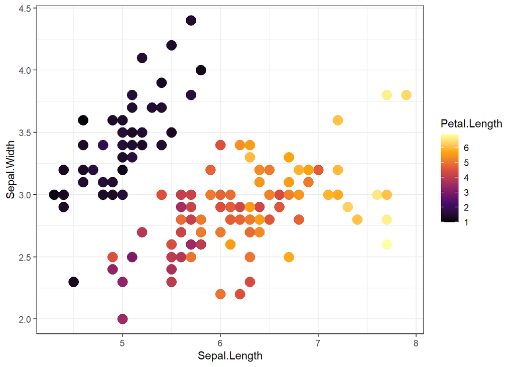

```r
iris %>%
  ggplot(mapping = aes(x = Sepal.Length, y = Sepal.Width)) +
  geom_point(mapping = aes(color = Petal.Length),
             size = 4.5) +
  scale_color_viridis_c(option = "inferno") +
  theme_bw()
```

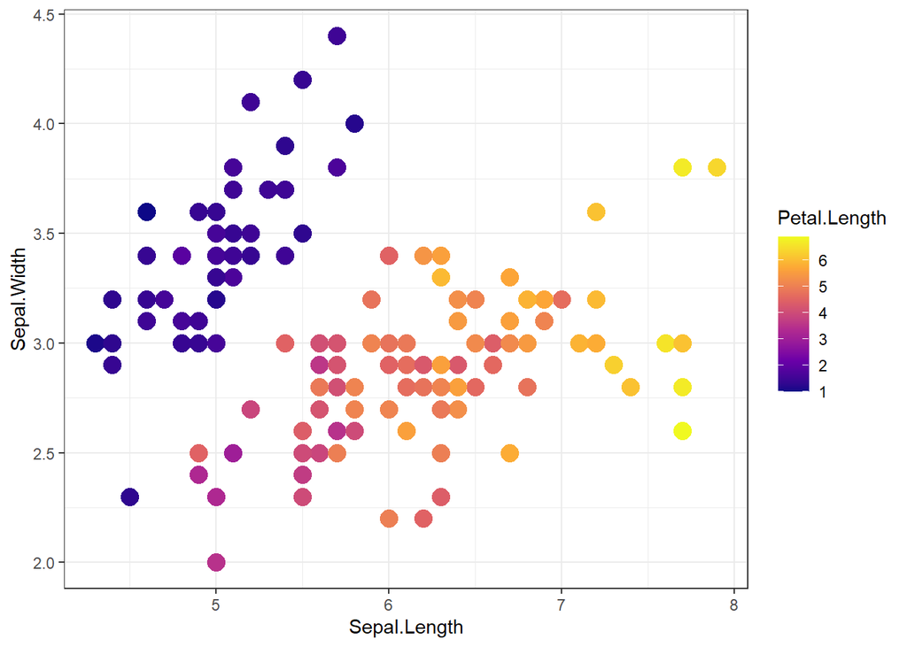

```r
iris %>%
  ggplot(mapping = aes(x = Sepal.Length, y = Sepal.Width)) +
  geom_point(mapping = aes(color = Petal.Length),
             size = 4.5) +
  scale_color_viridis_c(option = 'plasma') +
  theme_bw()
```

Sometimes we want to use a diverging color scale, if we are interested in the **directioin** away from a centrol or *midpoint*. We can create diviging color palettes with the `scale_color_gradient2()` function.

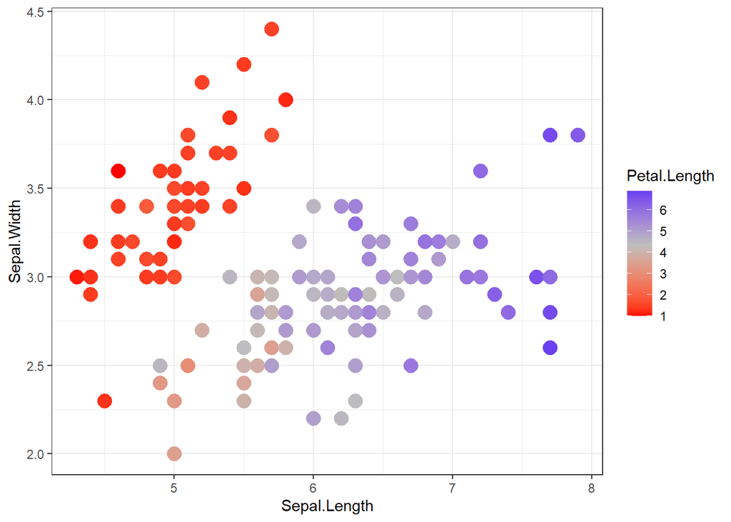

```r
iris %>%
  ggplot(mapping = aes(x = Sepal.Length, y = Sepal.Width)) +
  geom_point(mapping = aes(color = Petal.Length),
             size = 4.5) +
  scale_color_gradient2(low = 'red', mid = 'grey', high = 'blue',
                        midpoint = median(iris$Petal.Length)) +
  theme_bw()
```

Another common diverging palette is orange to grey to blue.

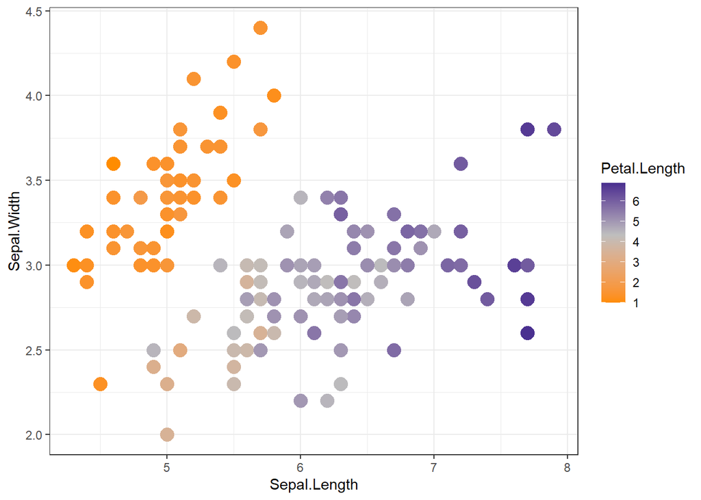

```r
iris %>%
  ggplot(mapping = aes(x = Sepal.Length, y = Sepal.Width)) +
  geom_point(mapping = aes(color = Petal.Length),
             size = 4.5) +
  scale_color_gradient2(low = 'darkorange', mid = 'grey', high = 'navyblue',
                        midpoint = median(iris$Petal.Length)) +
  theme_bw()
```

It’s also common to use white for the midpoint, but then we should dark background theme.

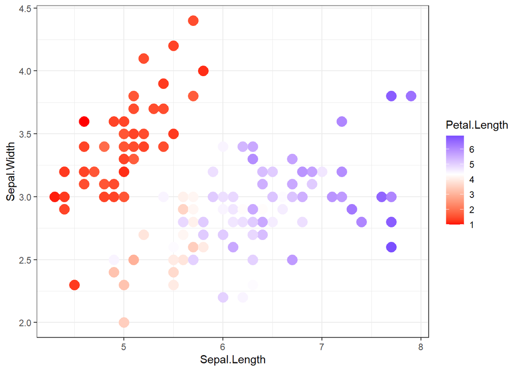

```r
iris %>%
  ggplot(mapping = aes(x = Sepal.Length, y = Sepal.Width)) +
  geom_point(mapping = aes(color = Petal.Length),
             size = 4.5) +
  scale_color_gradient2(low = 'red', mid = 'white', high = 'blue',
                        midpoint = median(iris$Petal.Length)) +
  theme_bw()
```

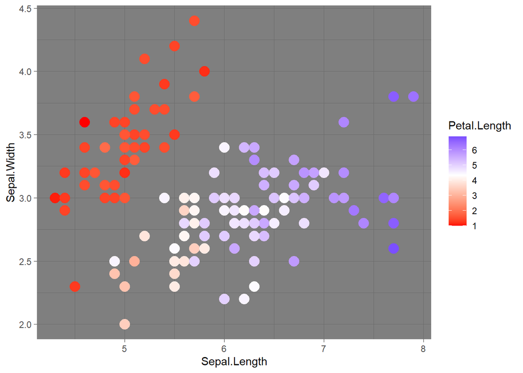

```r
iris %>%
  ggplot(mapping = aes(x = Sepal.Length, y = Sepal.Width)) +
  geom_point(mapping = aes(color = Petal.Length),
             size = 4.5) +
  scale_color_gradient2(low = 'red', mid = 'white', high = 'blue',
                        midpoint = median(iris$Petal.Length)) +
  theme_dark()
```

Return to the sequential color scale with viridis.

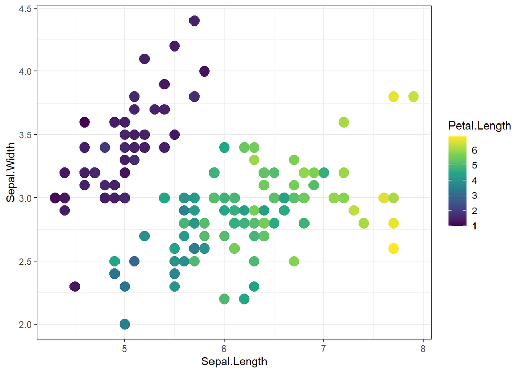

```r
iris %>%
  ggplot(mapping = aes(x = Sepal.Length, y = Sepal.Width)) +
  geom_point(mapping = aes(color = Petal.Length),
             size = 4.5) +
  scale_color_viridis_c(option = 'viridis') +
  theme_bw()
```

Sometimes it can be useful to “bin” or represent the continuous variable categorically with discrete color bins. Create “buckets” or “bins” of constant color where the value “jumps” across the bins.

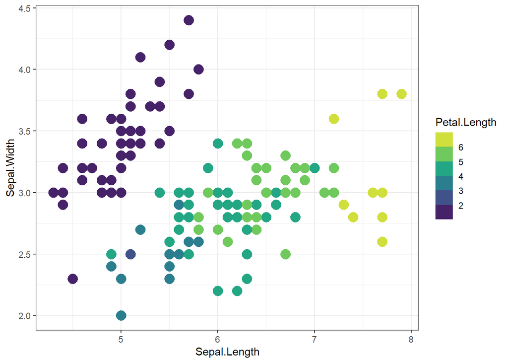

```r
iris %>%
  ggplot(mapping = aes(x = Sepal.Length, y = Sepal.Width)) +
  geom_point(mapping = aes(color = Petal.Length),
             size = 4.5) +
  scale_colour_viridis_b(option = 'viridis') +
  theme_bw()
```

We can create the bins ourselves and have more control. For example we can convert a continuous variable into a categorical variable with the `cut()` function. We can create the categorical variable directly within the `aes()` function.

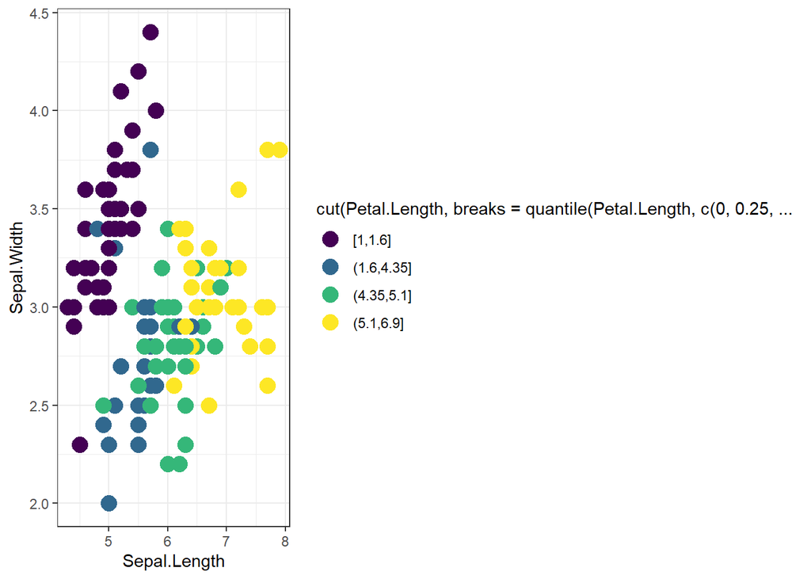

```r
iris %>%
  ggplot(mapping = aes(x = Sepal.Length, y = Sepal.Width)) +
  geom_point(mapping = aes(color = cut(Petal.Length,
                                       breaks = quantile(Petal.Length,
                                                         c(0, 0.25, 0.5, 0.75, 1.0)),
                                       include.lowest = TRUE)),
             size = 4.5) +
  scale_color_viridis_d() +
  theme_bw()
```

If we apply the `cut()` function ourselves we probably want to modify the legend title.

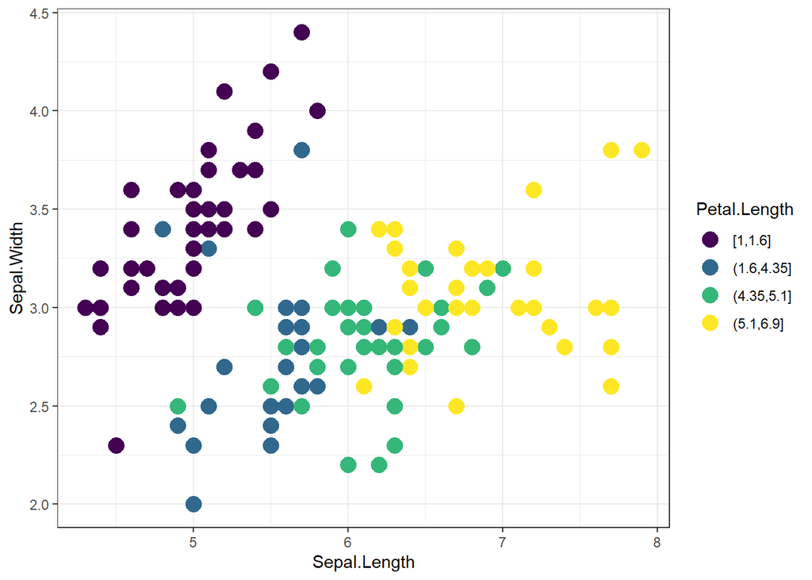

```r
iris %>%
  ggplot(mapping = aes(x = Sepal.Length, y = Sepal.Width)) +
  geom_point(mapping = aes(color = cut(Petal.Length,
                                       breaks = quantile(Petal.Length,
                                                         c(0, 0.25, 0.5, 0.75, 1.0)),
                                       include.lowest = TRUE)),
             size = 4.5) +
  scale_color_viridis_d("Petal.Length") +
  theme_bw()
```

The simplest way to convert a continuous variable into a categorical variable is through binarizing. Just show two ordered values. This is easy to apply with conditional statements directly the `aes()` function.  
For example, let’s compare `Petal.Length` to it’s median value.

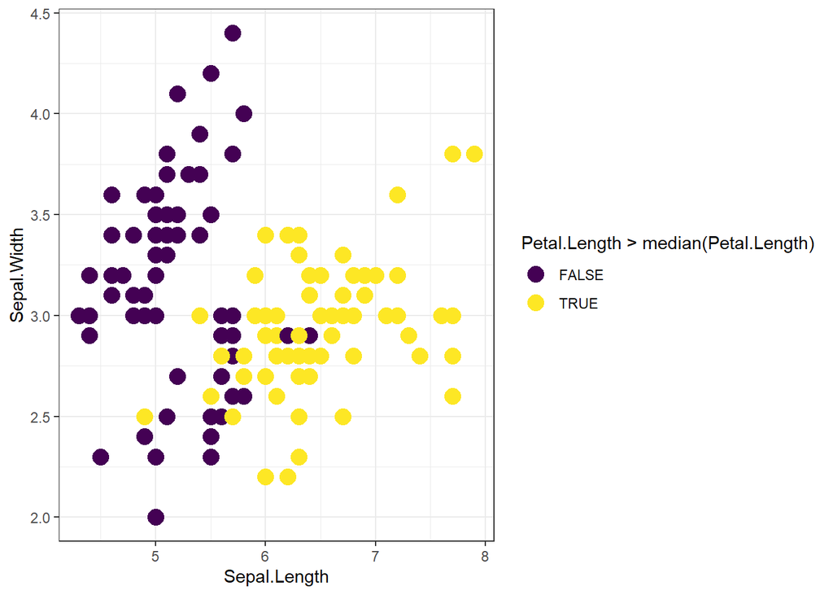

```r
iris %>%
  ggplot(mapping = aes(x = Sepal.Length, y = Sepal.Width)) +
  geom_point(mapping = aes(color = Petal.Length > median(Petal.Length)),
             size = 4.5) +
  scale_colour_viridis_d(option = 'viridis') +
  theme_bw()
```

Move the legend to the top.

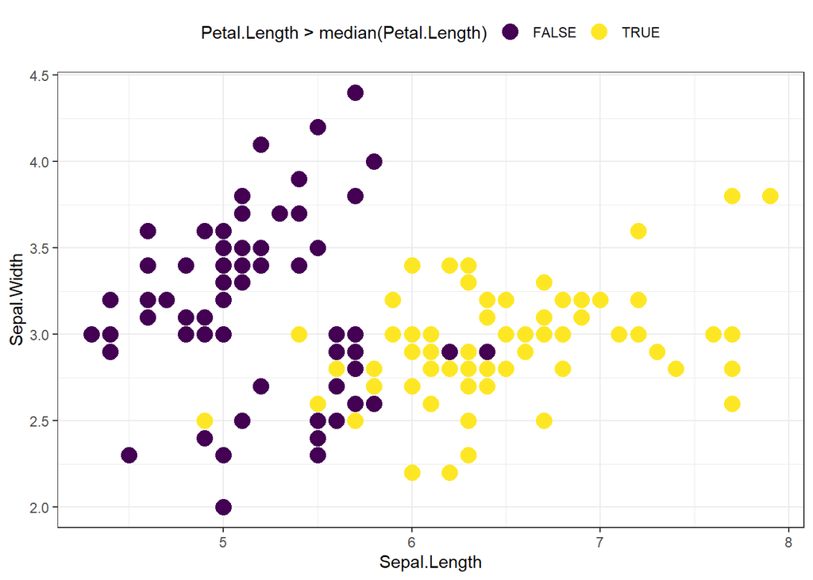

```r
iris %>%
  ggplot(mapping = aes(x = Sepal.Length, y = Sepal.Width)) +
  geom_point(mapping = aes(color = Petal.Length > median(Petal.Length)),
             size = 4.5) +
  scale_colour_viridis_d(option = 'viridis') +
  theme_bw() +
  theme(legend.position = "top")
```

Let’s combine using aesthetics of the `geom_point()` to show a continuous variable and a categorical variable together. We will use the color to denote the `Petal.Length` and the marker shape to denote the `Species`. Our plot will therefore communicate 4 variables at once!

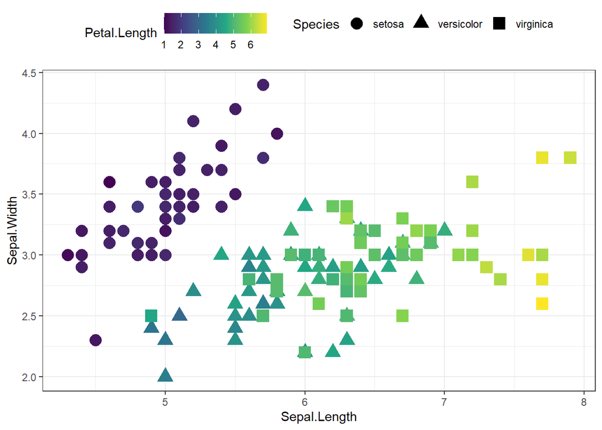

```r
iris %>%
  ggplot(mapping = aes(x = Sepal.Length, y = Sepal.Width)) +
  geom_point(mapping = aes(color = Petal.Length,
                           shape = Species),
             size = 4.5) +
  scale_color_viridis_c() +
  scale_shape_discrete() +
  theme_bw() +
  theme(legend.position = "top")
```

We have one more continuous variable to consider! Let’s use the facets to denote the `Species`.

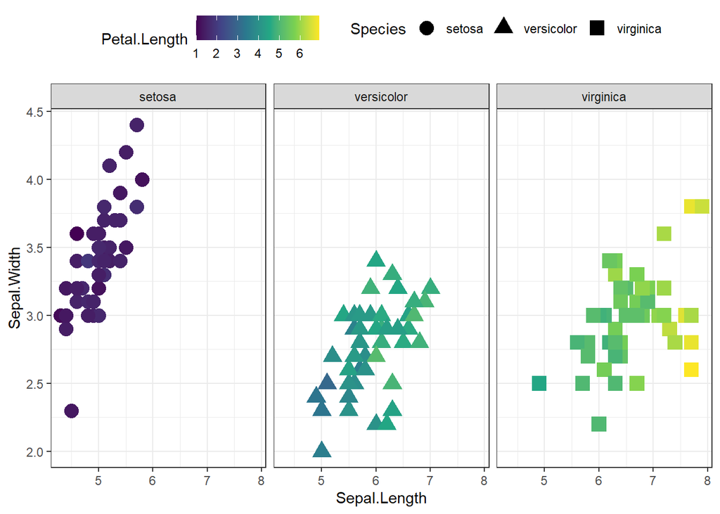

```r
iris %>%
  ggplot(mapping = aes(x = Sepal.Length, y = Sepal.Width)) +
  geom_point(mapping = aes(color = Petal.Length,
                           shape = Species),
             size = 4.5) +
  facet_wrap( ~ Species ) +
  scale_color_viridis_c() +
  scale_shape_discrete() +
  theme_bw() +
  theme(legend.position = "top")
```

We can use the marker shape to designate a binarized version of Petal.Width. Lets use the shape to denote if the Petal.Width is greater than its median.

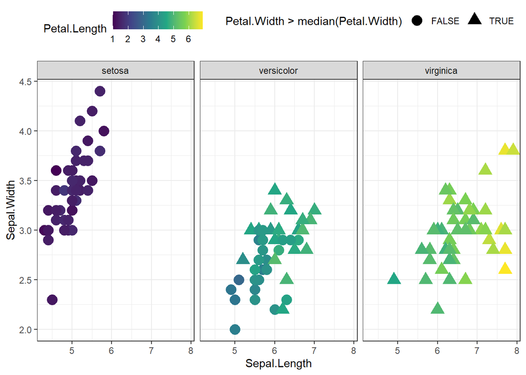

```r
iris %>%
  ggplot(mapping = aes(x = Sepal.Length, y = Sepal.Width)) +
  geom_point(mapping = aes(color = Petal.Length,
                           shape = Petal.Width > median(Petal.Width)),
             size = 4.5) +
  facet_wrap(~Species) +
  scale_color_viridis_c() +
  scale_shape_discrete() +
  theme_bw() +
  theme(legend.position = "top")
```

Maybe we should consider transparency to help look at data points that are “on top” of each other.

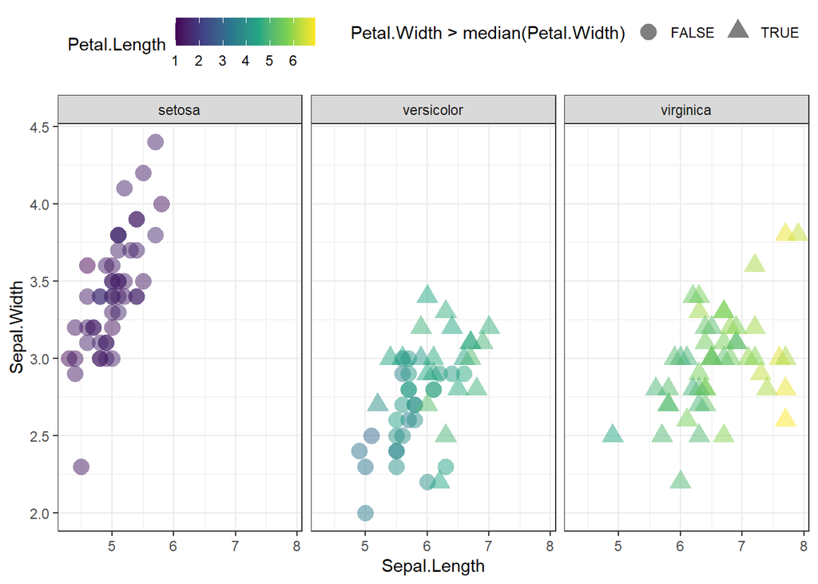

```r
iris %>%
  ggplot(mapping = aes(x = Sepal.Length, y = Sepal.Width)) +
  geom_point(mapping = aes(color = Petal.Length,
                           shape = Petal.Width > median(Petal.Width)),
             size = 4.5, alpha = 0.5) +
  facet_wrap(~Species) +
  scale_color_viridis_c() +
  scale_shape_discrete() +
  theme_bw() +
  theme(legend.position = "top")
```

Or, maybe we should use the facets to denote the Petal.Width binary variable.

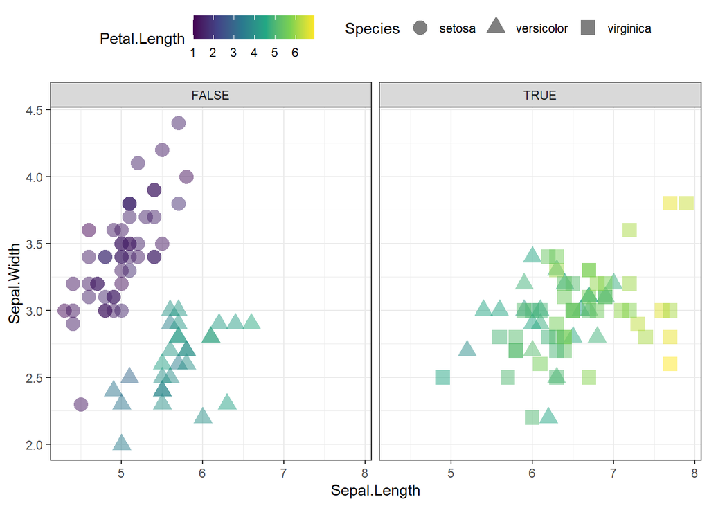

```r
iris %>%
  ggplot(mapping = aes(x = Sepal.Length, y = Sepal.Width)) +
  geom_point(mapping = aes(color = Petal.Length,
                           shape = Species),
             size = 4.5, alpha = 0.5) +
  facet_wrap(~Petal.Width > median(Petal.Width)) +
  scale_color_viridis_c() +
  scale_shape_discrete() +
  theme_bw() +
  theme(legend.position = "top")
```

Include the labels for the facet variable as well as the value in the facets.

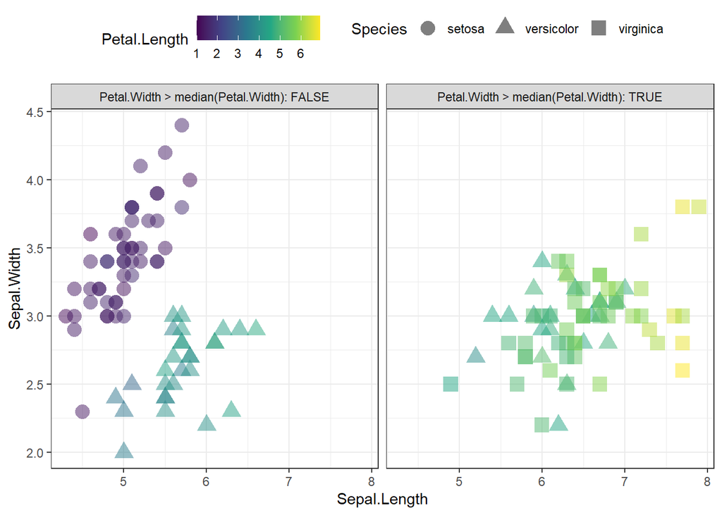

```r
iris %>%
  ggplot(mapping = aes(x = Sepal.Length, y = Sepal.Width)) +
  geom_point(mapping = aes(color = Petal.Length,
                           shape = Species),
             size = 4.5, alpha = 0.5) +
  facet_wrap(~Petal.Width > median(Petal.Width),
             labeller = "label_both") +
  scale_color_viridis_c() +
  scale_shape_discrete() +
  theme_bw() +
  theme(legend.position = "top")
```

Binarize the Petal.Length to small and larger values.

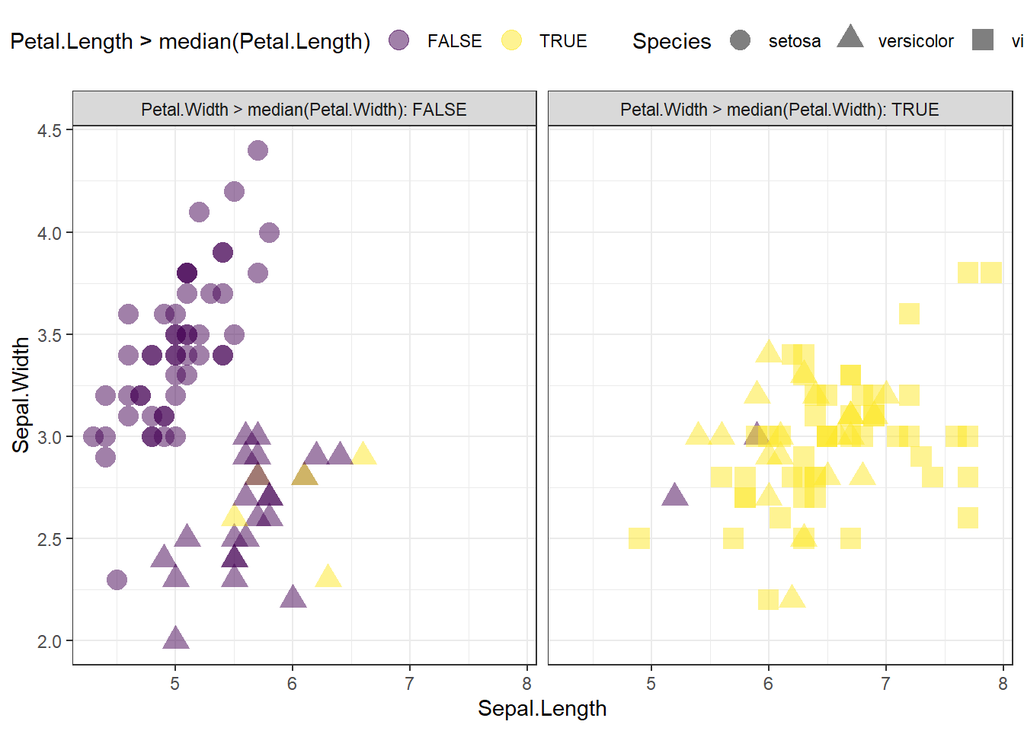

```r
iris %>%
  ggplot(mapping = aes(x = Sepal.Length, y = Sepal.Width)) +
  geom_point(mapping = aes(color = Petal.Length > median(Petal.Length),
                           shape = Species),
             size = 4.5, alpha = 0.5) +
  facet_wrap(~Petal.Width > median(Petal.Width),
             labeller = "label_both") +
  scale_color_viridis_d() +
  scale_shape_discrete() +
  theme_bw() +
  theme(legend.position = "top")
```